# Brisbane AirBnB Property Analysis

Rowena Hutchins

Aim: Conduct analysis of public AirBnB Brisbane Property Listings data Data source: https://data.insideairbnb.com/australia/qld/brisbane/2024-04-12/data/listings.csv.gz Data dictionary: https://docs.google.com/spreadsheets/d/1iWCNJcSutYqpULSQHlNyGInUvHg2BoUGoNRIGa6Szc4/edit

### First steps on extracting data

- Inspected file in Notepad
- Imported file into Excel Using Get Data feature to avoid unwanted data type changes
- Inspected data
- Copied header row and sample data
- Transposed into new sheet
- Identified columns required in specification, and appropriate data types
- Identified unnecessary columns
- Set up code for each column to either import with desired data type or skip =[fieldname]&” = col_“&[datatype]&”(),”
- Copied code into RStudio as part of read_csv() function
- Inspected imported data
- Note ‘Price’ initially imported as character due to $ symbol, for later conversion.

### Import desired columns in appropriate format

```r
library(tidyverse)
listings <- read_csv("listings.csv", na = "", col_types = cols(
  id = col_character(),
  listing_url = col_skip(),
  scrape_id = col_skip(),
  last_scraped = col_skip(),
  source = col_skip(),
  name = col_character(),
  description = col_character(),
  neighborhood_overview = col_skip(),
  picture_url = col_skip(),
  host_id = col_skip(),
  host_url = col_skip(),
  host_name = col_character(),
  host_since = col_skip(),
  host_location = col_skip(),
  host_about = col_skip(),
  host_response_time = col_skip(),
  host_response_rate = col_skip(),
  host_acceptance_rate = col_skip(),
  host_is_superhost = col_logical(),
  host_thumbnail_url = col_skip(),
  host_picture_url = col_skip(),
  host_neighbourhood = col_skip(),
  host_listings_count = col_skip(),
  host_total_listings_count = col_skip(),
  host_verifications = col_skip(),
  host_has_profile_pic = col_skip(),
  host_identity_verified = col_skip(),
  neighbourhood = col_skip(),
  neighbourhood_cleansed = col_character(),
  neighbourhood_group_cleansed = col_skip(),
  latitude = col_skip(),
  longitude = col_skip(),
  property_type = col_character(),
  room_type = col_character(),
  accommodates = col_integer(),
  bathrooms = col_skip(),
  bathrooms_text = col_character(),
  bedrooms = col_integer(),
  beds = col_integer(),
  amenities = col_character(),
  price = col_character(),
  minimum_nights = col_skip(),
  maximum_nights = col_skip(),
  minimum_minimum_nights = col_skip(),
  maximum_minimum_nights = col_skip(),
  minimum_maximum_nights = col_skip(),
  maximum_maximum_nights = col_skip(),
  minimum_nights_avg_ntm = col_skip(),
  maximum_nights_avg_ntm = col_skip(),
  calendar_updated = col_skip(),
  has_availability = col_skip(),
  availability_30 = col_skip(),
  availability_60 = col_skip(),
  availability_90 = col_skip(),
  availability_365 = col_skip(),
  calendar_last_scraped = col_skip(),
  number_of_reviews = col_integer(),
  number_of_reviews_ltm = col_integer(),
  number_of_reviews_l30d = col_skip(),
  first_review = col_skip(),
  last_review = col_skip(),
  review_scores_rating = col_double(),
  review_scores_accuracy = col_double(),
  review_scores_cleanliness = col_double(),
  review_scores_checkin = col_double(),
  review_scores_communication = col_double(),
  review_scores_location = col_double(),
  review_scores_value = col_double(),
  license = col_skip(),
  instant_bookable = col_skip(),
  calculated_host_listings_count = col_skip(),
  calculated_host_listings_count_entire_homes = col_skip(),
  calculated_host_listings_count_private_rooms = col_skip(),
  calculated_host_listings_count_shared_rooms = col_skip(),
  reviews_per_month = col_skip()
))

listings <- listings %>%
  mutate(price = gsub("[$,]","",price),
         price = if_else(price == "", NA_real_, as.numeric(price)))

summary(listings)
```

```
##       id                name           description         host_name
##  Length:4609        Length:4609        Length:4609        Length:4609
##  Class :character   Class :character   Class :character   Class :character
##  Mode  :character   Mode  :character   Mode  :character   Mode  :character
##
##
##
##
##  host_is_superhost neighbourhood_cleansed property_type       room_type
##  Mode :logical     Length:4609            Length:4609        Length:4609
##  FALSE:2889        Class :character       Class :character   Class :character
##  TRUE :1718        Mode  :character       Mode  :character   Mode  :character
##  NA's :2
##
##
##
##   accommodates    bathrooms_text        bedrooms           beds
##  Min.   : 1.000   Length:4609        Min.   : 0.000   Min.   : 0.00
##  1st Qu.: 2.000   Class :character   1st Qu.: 1.000   1st Qu.: 1.00
##  Median : 3.000   Mode  :character   Median : 1.000   Median : 2.00
##  Mean   : 3.657                      Mean   : 1.733   Mean   : 2.02
##  3rd Qu.: 4.000                      3rd Qu.: 2.000   3rd Qu.: 3.00
##  Max.   :16.000                      Max.   :15.000   Max.   :23.00
##                                      NA's   :74       NA's   :313
##   amenities             price         number_of_reviews number_of_reviews_ltm
##  Length:4609        Min.   :   12.0   Min.   :  0.00    Min.   :  0.00
##  Class :character   1st Qu.:  117.0   1st Qu.:  3.00    1st Qu.:  1.00
##  Mode  :character   Median :  169.0   Median : 16.00    Median :  8.00
##                     Mean   :  216.8   Mean   : 46.01    Mean   : 15.49
##                     3rd Qu.:  240.0   3rd Qu.: 52.00    3rd Qu.: 22.00
##                     Max.   :10947.0   Max.   :985.00    Max.   :272.00
##                     NA's   :308
##  review_scores_rating review_scores_accuracy review_scores_cleanliness
##  Min.   :1.000        Min.   :1.000          Min.   :1.000
##  1st Qu.:4.630        1st Qu.:4.700          1st Qu.:4.590
##  Median :4.820        Median :4.860          Median :4.810
##  Mean   :4.727        Mean   :4.767          Mean   :4.698
##  3rd Qu.:4.950        3rd Qu.:4.970          3rd Qu.:4.960
##  Max.   :5.000        Max.   :5.000          Max.   :5.000
##  NA's   :608          NA's   :619            NA's   :619
##  review_scores_checkin review_scores_communication review_scores_location
##  Min.   :1.000         Min.   :1.000               Min.   :1.000
##  1st Qu.:4.710         1st Qu.:4.800               1st Qu.:4.750
##  Median :4.890         Median :4.930               Median :4.880
##  Mean   :4.775         Mean   :4.837               Mean   :4.816
##  3rd Qu.:5.000         3rd Qu.:5.000               3rd Qu.:4.970
##  Max.   :5.000         Max.   :5.000               Max.   :5.000
##  NA's   :619           NA's   :619                 NA's   :619
##  review_scores_value
##  Min.   :1.000
##  1st Qu.:4.570
##  Median :4.760
##  Mean   :4.671
##  3rd Qu.:4.900
##  Max.   :5.000
##  NA's   :619
```

### Count listing that meet specific criteria

Count the number of listings matching the following criteria: a. Listings with ‘Airport’ in their name (ignoring case sensitivity). b. Listings with ‘Airport’ and ‘CBD’ in their name (ignoring case sensitivity).

```r
count_airport <- sum(str_detect(str_to_lower(listings$name),"airport"))
print("Listings with 'airport' in their name:")
```

```
## [1] "Listings with 'airport' in their name:"
```

```r
count_airport
```

```
## [1] 83
```

```r
count_airport_and_cbd <- sum(
  str_detect(str_to_lower(listings$name),"airport") &
  str_detect(str_to_lower(listings$name),"cbd")
  )
print("Listings with 'airport' and 'CBD' in their name:")
```

```
## [1] "Listings with 'airport' and 'CBD' in their name:"
```

```r
count_airport_and_cbd
```

```
## [1] 9
```

### Top ten neighbourhoods by review numbers

Include average review score rating.

```r
top_ten_neighbourhoods <- listings %>%
  group_by(neighbourhood=neighbourhood_cleansed) %>%
  summarise(
    reviews = sum(number_of_reviews, na.rm = TRUE),
    av_rating = round(mean(review_scores_rating, na.rm = TRUE),3)
    ) %>%
  arrange(desc(reviews)) %>%
  head(10)

top_ten_neighbourhoods
```

```
## # A tibble: 10 × 3
##    neighbourhood          reviews av_rating
##    <chr>                    <int>     <dbl>
##  1 South Brisbane           33960      4.68
##  2 Brisbane City            26912      4.70
##  3 Fortitude Valley         17613      4.71
##  4 Spring Hill               8776      4.70
##  5 Newstead - Bowen Hills    8061      4.74
##  6 New Farm                  6471      4.82
##  7 West End                  6408      4.79
##  8 Paddington - Milton       5847      4.75
##  9 Kangaroo Point            5444      4.60
## 10 Woolloongabba             3724      4.72
```

### Compare review scores and counts of Superhost vs non-superhost

```r
reviews_by_host_status <- listings %>%
  group_by(host_status=host_is_superhost) %>%
  summarise(
    av_rating = round(mean(review_scores_rating, na.rm = TRUE),3),
    review_count = sum(number_of_reviews, na.rm = TRUE)
    )

reviews_by_host_status <- reviews_by_host_status %>%
  mutate(host_status = case_when(
    host_status == TRUE ~ "Superhost",
    host_status == FALSE ~ "non-Superhost",
    is.na(host_status) ~ "Unknown"
    ))

reviews_by_host_status$host_status <- factor(reviews_by_host_status$host_status, c("Superhost","non-Superhost","Unknown"))

reviews_by_host_status <- reviews_by_host_status %>%
  arrange(host_status)

reviews_by_host_status
```

```
## # A tibble: 3 × 3
##   host_status   av_rating review_count
##   <fct>             <dbl>        <int>
## 1 Superhost          4.87       107896
## 2 non-Superhost      4.63       104173
## 3 Unknown            4.58            5
```

### Wynnum properties

Display the average price and average review score rating of each property type in ‘Wynnum’.

```r
Wynnum_properties <- listings %>%
  filter(neighbourhood_cleansed == "Wynnum") %>%
  group_by(property_type) %>%
  summarise(
    av_price = round(mean(price, na.rm = TRUE),2),
    av_rating = round(mean(review_scores_rating, na.rm = TRUE),3)
    )

Wynnum_properties
```

```
## # A tibble: 11 × 3
##    property_type               av_price av_rating
##    <chr>                          <dbl>     <dbl>
##  1 Entire condo                   134.       4.71
##  2 Entire guest suite             132.       4.92
##  3 Entire guesthouse              150.       4.69
##  4 Entire home                    433.       4.76
##  5 Entire rental unit             199.       4.90
##  6 Entire serviced apartment      275        5
##  7 Entire townhouse               250        4.97
##  8 Entire villa                   800        5
##  9 Private room in condo           73        5
## 10 Private room in home            75.6      4.03
## 11 Private room in rental unit    111.       4.9
```

### Find accommodation options in West End

Chosen criteria: Neighbourhood - West End Max price - $400 Property type - entire rental unit or entire home Required amenities - single level home with self check-in Accommodates - at least 4 people

```r
#filter for desired criteria
filtered_properties <- listings %>%
  filter(neighbourhood_cleansed == "West End") %>%
  filter(price <= 400) %>%
  filter(property_type == "Entire rental unit" | property_type == "Entire home") %>%
  filter(accommodates >= 4) %>%
  filter(
    str_detect(str_to_lower(amenities),"single level home") &
    str_detect(str_to_lower(amenities),"self check-in")
    )

#select fields
accommodation_options <- filtered_properties[, c(
  "name",
  "neighbourhood_cleansed",
  "price",
  "property_type",
  "accommodates",
  "amenities")]

accommodation_options <- accommodation_options %>%
  rename(neighbourhood = neighbourhood_cleansed)

accommodation_options
```

```
## # A tibble: 7 × 6
##   name                  neighbourhood price property_type accommodates amenities
##   <chr>                 <chr>         <dbl> <chr>                <int> <chr>
## 1 West end Charm 5 bed… West End        383 Entire home             10 "[\"Sing…
## 2 Walk to River, Cute … West End        199 Entire renta…            4 "[\"Sing…
## 3 Riverfront Elegance!… West End        335 Entire renta…            4 "[\"Sing…
## 4 West End Rooftop poo… West End        191 Entire renta…            4 "[\"Clot…
## 5 Montague Metropolita… West End        213 Entire renta…            4 "[\"Clot…
## 6 2BR Central South Br… West End        182 Entire renta…            4 "[\"Sing…
## 7 Chic New Apt near So… West End        209 Entire renta…            5 "[\"Sing…
```

### Show bar chart of listings by property type

```r
listings_per_property_type <- listings %>%
  group_by(property_type) %>%
  summarise(
    num_listings = n()) %>%
  arrange(desc(num_listings)) %>%
  head(10)

listings_per_property_type
```

```
## # A tibble: 10 × 2
##    property_type               num_listings
##    <chr>                              <int>
##  1 Entire rental unit                  2120
##  2 Entire home                          678
##  3 Private room in home                 620
##  4 Private room in rental unit          242
##  5 Entire guest suite                   178
##  6 Entire serviced apartment            145
##  7 Entire guesthouse                    108
##  8 Entire condo                          71
##  9 Entire townhouse                      58
## 10 Private room in townhouse             54
```

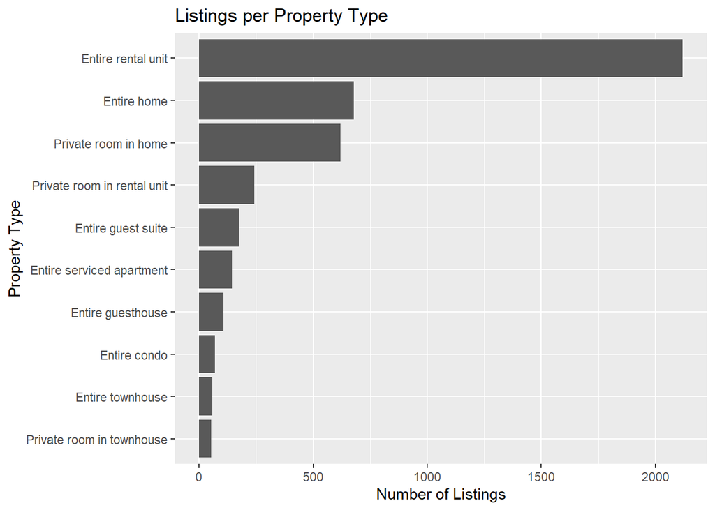

```r
listings_per_property_type %>%
  mutate(property_type = factor(property_type, levels = rev(property_type))) %>%
  ggplot() +
  aes(x = num_listings, y = property_type) +
  geom_col() +
  labs(x = "Number of Listings", y = "Property Type", title = "Listings per Property Type")
```

Summary of insights:

Research that could be conducted with the current data set could include: - Correlation between booking popularity and listing numbers: are there more units due to supply or demand?

(The smaller end of the scale might also be worth investigation. Interestingly, the data set includes 1 castle, 1 island and 1 cave, but surprisingly 2 private rooms in caves.)

### Analyse review scores based on various categories

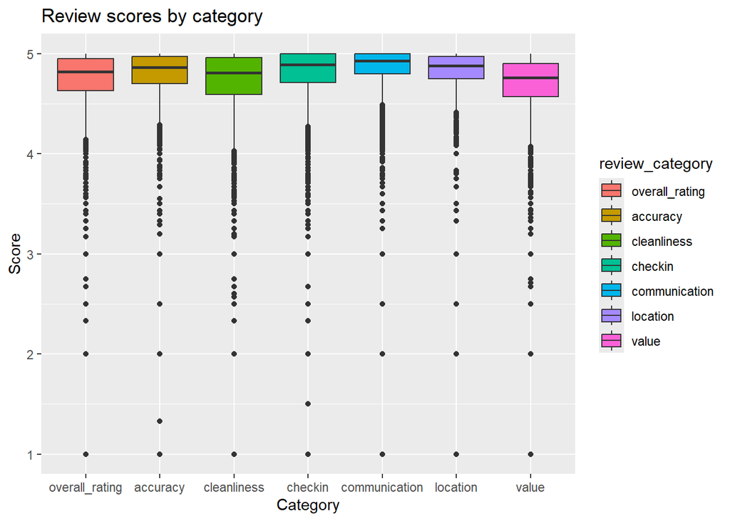

```r
#First, review data is pivoted into long format

listings_long <- listings %>%
  pivot_longer(
    cols = starts_with("review_scores_"),
    names_to = "review_category",
    names_prefix = "review_scores_",
    values_to = "review_scores"
  )

review_data <- listings_long[, c(
  "review_category",
  "review_scores")]

review_data$review_category <- replace(review_data$review_category, review_data$review_category == "rating","overall_rating")

review_data$review_category <- factor(review_data$review_category, c(
  "overall_rating",
  "accuracy",
  "cleanliness",
  "checkin",
  "communication",
  "location",
  "value"))

review_data <- review_data %>%
  arrange(review_category)

#filter out rows where revew_score is blank
review_data <- review_data %>%
  filter(is.finite(review_scores))

#Plot review data as a series of box plots
ggplot(review_data) +
    aes(x = review_category, y = review_scores, fill = review_category) +
    geom_boxplot() +
    labs(title = "Review scores by category", x = "Category", y = "Score")
```

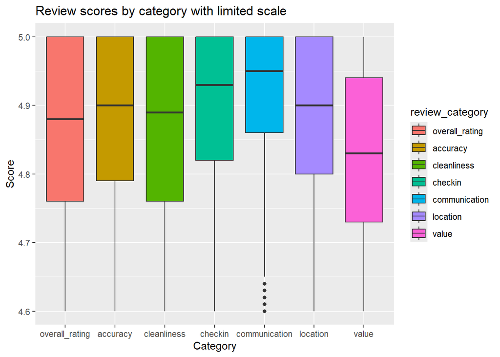

```r
#Limit box plot range
ggplot(review_data) +
    aes(x = review_category, y = review_scores, fill = review_category) +
    ylim(4.6,5.0) +
    geom_boxplot() +
    labs(title = "Review scores by category with limited scale", x = "Category", y = "Score")
```

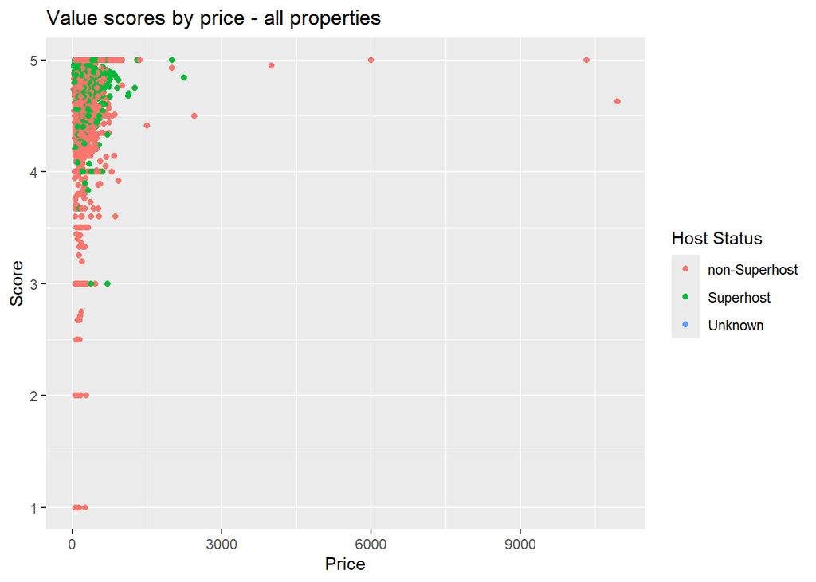

```r
#Plot value scores against price and host status
listings2 <- listings %>%
  mutate(host_is_superhost = case_when(
    host_is_superhost == TRUE ~ "Superhost",
    host_is_superhost == FALSE ~ "non-Superhost",
    is.na(host_is_superhost) ~ "Unknown"
    ))
ggplot(listings2) +
  aes(x = price, y = review_scores_value, color = host_is_superhost) +
  geom_point() +
  labs(title = "Value scores by price - all properties", x = "Price", y = "Score", color = "Host Status")
```

[output not shown]

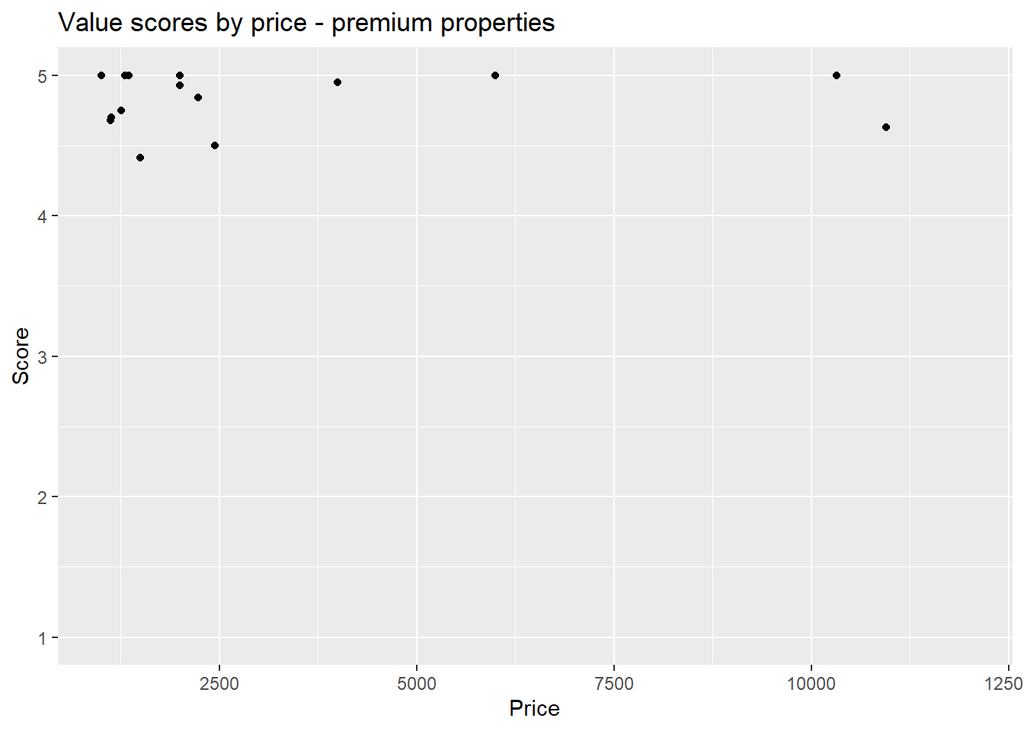

```r
#Limit scatter plot domain to focus on premium properties
ggplot(listings2) +
  aes(x = price, y = review_scores_value) +
  xlim(1000,12000) +
  geom_point() +
  labs(title = "Value scores by price - premium properties", x = "Price", y = "Score")
```

Note - limiting ranges generates a warning that some data is omitted, but allows us to focus analysis on particular parts of the distribution. Titles indicate data set limitations.

### Summary

After filtering out blank review scores, we have 27,941 data points. The vast majority of reviews are above 4.6. Limiting the box plot range to 4.6 to 5.0 only cuts off 5.066 data points, but gives a much clearer picture of score distribution, particularly for the second and third quartiles.

Looking at the value score compared to price and host status, it is clear that premium properties score high on value, despite ranging in price to over $10,000. Super-host properties score 3 or above.

Overall there is not much variation in review scores, and better measures of quality and satisfaction may exist, such as frequency of re-booking. However, given the lack of variation, a review score of three or below should probably be treated with caution when selecting a property.